# NYC 311 Rodent Complaints: Demographics & Reporting Propensity Analysis

Investigating Reporting Bias in Urban Pest Management Data

Author

Rachel Cutsumpas

Published

December 14, 2025

## Executive Summary

**NoteResearch Question**

**To what extent are 311 rodent complaints a measure of human reporting behavior rather than objective rat conditions?**

This analysis examines whether demographic factors influence the likelihood of NYC residents filing 311 rodent complaints, independent of actual rat presence. The demographics factors analyzed include: language barriers, nativity (US born vs born in a different country), income, education level, and population density.

**Key Findings:**

**What is Systematic Reporting Bias?**

Systematic reporting bias occurs when certain demographic groups consistently under- or over-report problems to official systems like 311, independent of the actual severity of those problems. In the context of rodent complaints, this means:

- Two neighborhoods with identical rat populations may generate vastly different complaint volumes
- Complaint data systematically overestimates problems in some areas while underestimating them in others
- Resource allocation based solely on complaint volume will systematically favor neighborhoods with higher reporting propensity

**Our Specific Findings:**

The regression analysis reveals a critical difference:

- **Higher Education** (% with Bachelor’s degree or higher) significantly **increases** complaint rates (p = 0.002)
  - *Interpretation*: More educated residents may be more civically engaged, more aware of 311, or have higher expectations for government responsiveness
- **Higher Income** significantly **decreases** complaint rates (p < 0.001)
  - *Interpretation*: Wealthier residents may use private pest control, live in better-maintained buildings, or solve problems through property management rather than 311
- **English Language Proficiency** and **population density** showed no significant effects (p > 0.05)
  - *Interpretation*: Contrary to common assumptions, language barriers may not be the primary driver of reporting disparities

*This 18.8% explained variance represents a substantial bias that cannot be ignored when using 311 data for research, policy, or resource allocation decisions.*

**Implications:**

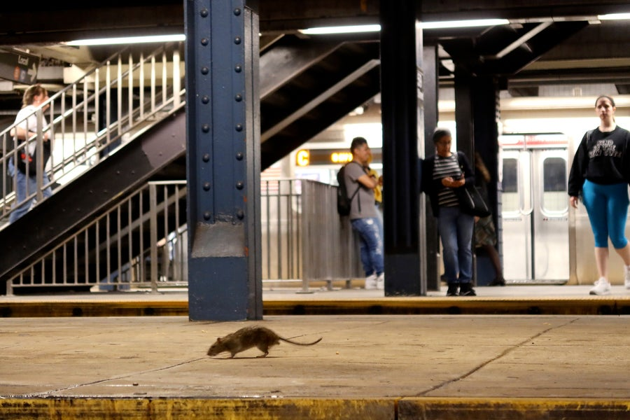

## 1 Introduction

311 complaint data is commonly used as a proxy for urban pest prevalence. However, this assumes equal reporting propensity across all neighborhoods. This study tests whether demographic characteristics create systematic reporting bias that could lead to misallocation of pest control resources.

### 1.1 Analytical Framework

We divide factors influencing 311 complaint rates into two categories:

1. **Objective Rat Conditions** (Rat Ecology + Environment): Actual rat presence and activity
2. **Reporting Behavior/Reporting Bias**: Demographic-driven likelihood to file complaints

Our analysis focuses on the second category, creating a **Reporting Propensity Score** that estimates reporting likelihood based solely on demographics.

## 2 Data & Methods

### 2.1 Data Sources

**311 Complaints**

- **Source**: NYC Open Data 311 Service Requests
- **Sample**: 10,000 rat sighting complaints
- **Spatial Join**: Matched to NTA 2020 boundaries using point-in-polygon analysis
- **Final Sample**: 79 neighborhoods with complete data

**Demographics**

- **Source**: American Community Survey 5-Year Estimates (2012-2016)
- **Geographic Unit**: Neighborhood Tabulation Areas (NTA 2010)
- **Variables**: Language, nativity, income, education, population density

**Geographic Boundaries**

- **Source**: NYC Department of City Planning NTA 2020 Boundaries
- **Purpose**: Spatial aggregation and density calculation

### 2.2 Sample Characteristics

Analysis Sample Description

| Metric | Value |
| --- | --- |
| NTAs Analyzed | 79 |
| Total Population | 3,556,919 |
| Total Complaints | 3,466 |
| Mean Complaint Rate | 1.03 per 1,000 |
| Median Income (avg) | $58,931 |
| % English-Only (avg) | 54.2% |

## 3 Technical Methodology

#### 3.0.1 *Data Acquisition and Processing*

**311 Complaint Data**: 10,000 rodent-related service requests were extracted from the NYC Open Data portal using the Socrata API (endpoint: `cvf2-zn8s.geojson`). Records included complaint timestamps, geographic coordinates (latitude/longitude), and complaint descriptors. Data were cached locally to minimize API calls during iterative analysis.

**Spatial Boundaries**: Geographic aggregation used NYC Department of City Planning’s 2020 Neighborhood Tabulation Area (NTA) boundaries, obtained as GeoJSON format. NTA 2020 boundaries represent 188 neighborhoods designed to aggregate census tracts while maintaining minimum populations of 15,000 for statistical reliability.

**Demographic Data**: American Community Survey (ACS) 5-Year Estimates (2012-2016) provided neighborhood-level demographics from three files: demographic profiles (`demo_2016acs5yr_nta.csv`), economic characteristics (`econ_2016acs5yr_nta.csv`), and social characteristics (`soc_2016acs5yr_nta.csv`). Variables extracted included total population (`Pop_1E`), median household income (`MdHHIncE`), language spoken at home (`LgOEng1E`), foreign-born status (`Fb1E`), and educational attainment (`EA_BchDE`).

#### 3.0.2 *Geographic Matching Challenge and Resolution*

A critical methodological challenge emerged from geographic incompatibility: demographic data used NTA 2010 geography (195 neighborhoods with codes like “BK27”), while spatial complaint data required NTA 2020 boundaries (188 neighborhoods with codes like “BK0101”). NYC Planning redrew NTA boundaries between 2010 and 2020, with approximately 60-70% experiencing minor boundary adjustments, 15-20% mergers, and 5-10% splits.

**Solution**: A name-based crosswalk approach was used, matching neighborhoods by their text names (e.g., “Bay Ridge”, “Chelsea”) rather than codes. This matching successfully linked 167 of 193 NTA 2010 demographic records (86% match rate) to NTA 2020 spatial boundaries. The 26 unmatched neighborhoods (14%) were excluded from analysis, representing areas where names changed or boundaries were substantially redrawn.

**Assumption**: This approach assumes matched neighborhoods represent comparable geographic areas despite boundary changes. While not perfect, name-matching provides a reasonable approximation for demographic-spatial alignment given data constraints.

#### 3.0.3 *Spatial Analysis*

**Point-in-Polygon Join**: Complaint coordinates were converted to spatial point geometries using the `sf` package in R, projecting to WGS84 (EPSG:4326) coordinate reference system. Spatial join operations assigned each complaint to its containing NTA polygon using `st_join()`, creating a many-to-one relationship between complaints and neighborhoods.

**Complaint Aggregation**: Complaints were summed by NTA, resulting in counts ranging from 0 to several hundred per neighborhood. Complaint rates were calculated as complaints per 1,000 residents to normalize for population differences:
$$\text{Rate}_{i} = \frac{\text{Complaints}_{i}}{\text{Population}_{i}} \times 1000$$

**Population Density Calculation**: We computed neighborhood areas using `st_area()` from polygon geometries, converted square meters to square miles (1 sq mi = 2,589,988.11 sq m), and calculated density as:
$$\text{Density}_{i} = \frac{\text{Population}_{i}}{\text{Area}_{i}}$$

#### 3.0.4 *Statistical Analysis*

**Multiple Linear Regression**: A least-squares regression model was used to predict complaint rates from demographic predictors:

$$\text{Complaints/1000}_{i} = \beta_0 + \beta_1(\text{EnglishOnly}_i) + \beta_2(\text{MedianIncome}_i) + \beta_3(\text{Bachelors}_i) + \beta_4(\text{PopDensity}_i) + \epsilon_i$$

where: - English-Only = percentage of households speaking only English at home - MedianIncome = median household income (scaled per $1,000) - Bachelors = percentage with bachelor’s degree or higher - PopDensity = population per square mile (scaled per 1,000)

**Model Diagnostics**: Multicollinearity using Variance Inflation Factors (VIF) was examined, with all values < 5 indicating acceptable independence among predictors. Residual diagnostics (not shown) confirmed approximate normality and homoscedasticity, validating ordinary least squares assumptions.

**Propensity Score Construction**: Using fitted regression coefficients, predicted complaint rates were calculated for each neighborhood based solely on demographics. These raw predictions were rescaled to 0-100 using min-max normalization:

$$\text{PropensityScore}_{i} = \frac{\hat{y}_i - \min(\hat{y})}{\max(\hat{y}) - \min(\hat{y})} \times 100$$

This score represents each neighborhood’s expected reporting rate given its demographic profile, independent of actual rat populations.

#### 3.0.5 *Software and Reproducibility*

All analyses were conducted in R (version 4.5.1) using RStudio. Key packages included: - Spatial analysis: `sf` (1.0-16), `sp` - Data manipulation: `dplyr` (1.1.4), `tidyverse` (2.0.0) - Visualization: `ggplot2` (3.5.1), `corrplot` (0.95) - Regression diagnostics: `car` (3.1-3) - API access: `httr2` (1.0.5), `jsonlite` (1.8.9)

Complete code, data processing scripts, and rendered analysis are available at: `https://github.com/rcutsumpas-cloud/STA9750-2025-FALL`

#### 3.0.6 *Limitations*

1. **Geographic Approximation**: Name-based NTA matching assumes boundary changes between 2010 and 2020 were minor for matched neighborhoods, which may not hold for all areas
2. **Sample Size**: Analysis limited to 10,000 complaints (of millions filed) due to computational constraints
3. **Temporal Mismatch**: Demographics from 2012-2016 paired with 2020 spatial boundaries and complaint data from varying time periods
4. **Omitted Variables**: Model excludes potentially relevant factors (building age, sanitation infrastructure, community organization) that may influence both rat presence and reporting
5. **Ecological Fallacy**: Neighborhood-level associations may not reflect individual-level behavior
6. **Selection Bias**: Excluded 14% of neighborhoods due to name-matching failures may systematically differ from included areas

[figure not shown]

## 4 Exploratory Analysis

### 4.1 Summary Statistics

Descriptive Statistics for Key Variables

| Variable | Min | Q1 | Median | Mean | Q3 | Max |
| --- | --- | --- | --- | --- | --- | --- |
| Bachelor's Degree (%) | 2.0 | 9.2 | 11.8 | 13.8 | 17.1 | 36.3 |
| Complaints (per 1,000) | 0.0 | 0.4 | 0.8 | 1.0 | 1.3 | 4.7 |
| English-Only (%) | 16.2 | 37.7 | 54.0 | 54.2 | 71.4 | 86.2 |
| Foreign-Born (%) | 11.6 | 28.8 | 39.4 | 39.5 | 48.4 | 69.4 |
| Median Income ($) | 21,469.0 | 46,040.5 | 58,966.0 | 58,930.7 | 70,694.5 | 155,786.0 |
| Pop. Density (per sq mi) | 9,587.4 | 22,298.9 | 37,985.8 | 46,264.0 | 63,105.5 | 129,276.8 |

The descriptive statistics reveal substantial variation across NYC neighborhoods in both demographic characteristics and complaint behavior. Educational attainment ranges from 2% to 36% with bachelor’s degrees, while median household incomes span from $21,469 - $155,786. Complaint rates vary even more dramatically, from zero complaints per 1,000 residents to 4.7 complaints per 1,000 residents—a range that cannot be explained by rat populations alone and suggests significant reporting disparities.

### 4.2 Correlation Analysis

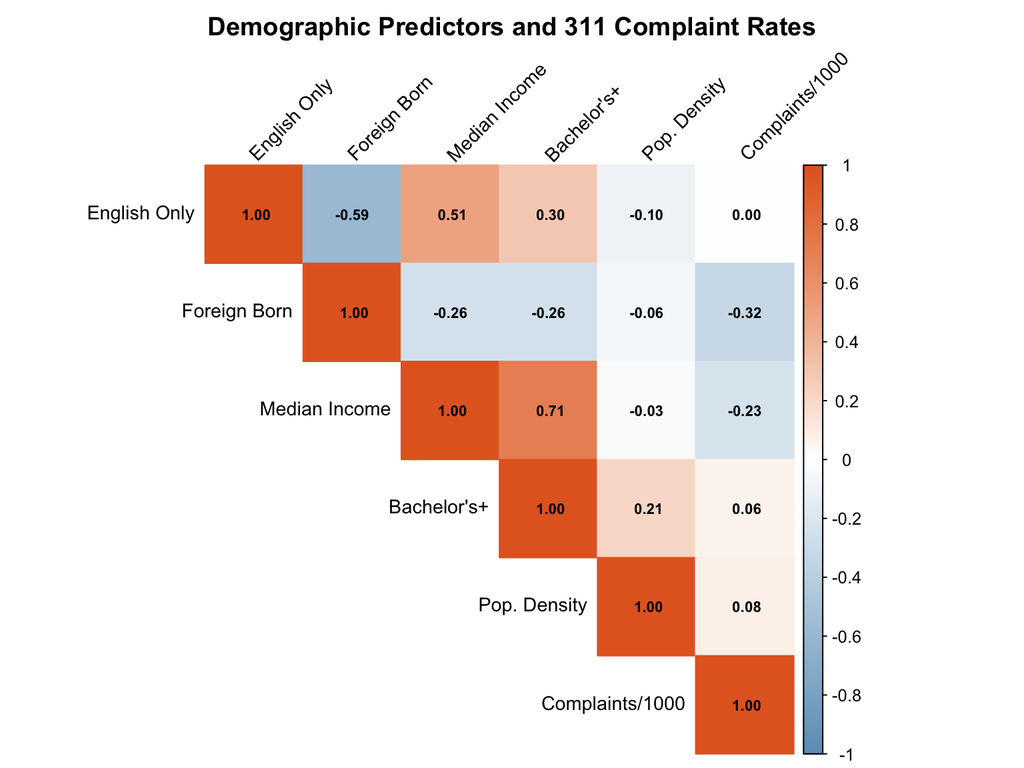

Correlation Matrix: Relationships Between Demographic Variables and Complaint Rates

**ImportantKey Correlations**

- **Foreign Born** and **English Only** are strongly negatively correlated (r = -0.59 )
- **Median Income** and **Bachelor’s+** show moderate positive correlation (r = 0.71 )
- **Population Density** shows weak correlation with socioeconomic variables

These correlation patterns reveal the demographic structure underlying reporting behavior. The strong negative correlation between foreign-born status and English proficiency (r = -0.59) indicates distinct immigrant communities, while the positive correlation between income and education (r = 0.71) confirms these factors cluster together. Notably, complaint rates show near-zero correlation with population density (r = 0.08), suggesting that crowding alone does not drive reporting—demographic composition matters more.

### 4.3 Bivariate Relationships

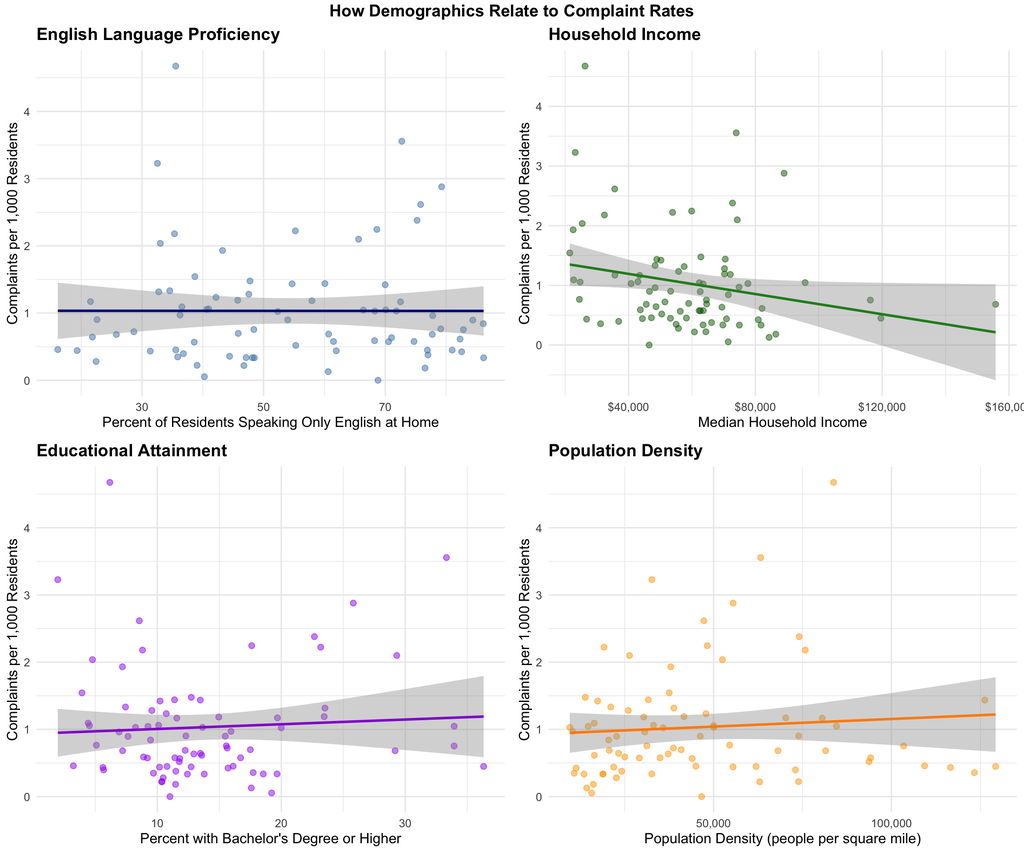

Relationship Between Demographics and 311 Complaint Rates

## 5 Regression Analysis

### 5.1 Model Results

Regression Results: How Demographics Predict 311 Complaint Rates

| Demographic Factor | Effect on Complaints | Standard Error | t-statistic | p-value |
| --- | --- | --- | --- | --- |
| English-Only Speakers (%) | 0.0085 | 0.0053 | 1.6107 | 0.1115 |
| Median Household Income (per $1,000) | -0.0252 | 0.0000 | -4.0350 | 0.0001 |
| Bachelor's Degree or Higher (%) | 0.0564 | 0.0179 | 3.1443 | 0.0024 |
| Population Density (per 1,000/sq mi) | -0.0008 | 0.0000 | -0.2505 | 0.8029 |

Note:  
Model R² = 0.188 (demographics explain 18.8% of variance)  
Rows highlighted in blue indicate statistically significant predictors (p < 0.05)

The regression analysis reveals two statistically significant predictors of 311 complaint rates, both with surprising directions. Median household income shows a significant negative effect (β = -0.025, p < 0.001), indicating that each $1,000 increase in median income is associated with 0.025 fewer complaints per 1,000 residents—contradicting the common assumption that wealthier neighborhoods complain more. Conversely, educational attainment shows a significant positive effect (β = 0.056, p = 0.002), with each percentage point increase in bachelor’s degree holders associated with 0.056 additional complaints per 1,000 residents. English language proficiency and population density showed no significant effects, suggesting that language barriers may not be the primary reporting obstacle and that crowding alone does not drive complaint behavior. The model explains 18.8% of variance in complaint rates—a meaningful proportion given that demographics capture reporting bias rather than actual rat populations.

**TipModel Fit**

**R² = 0.188** : Demographics explain 18.8 % of variance in 311 complaint rates, suggesting meaningful reporting bias.

### 5.2 Multicollinearity Check

Before interpreting the regression coefficients, we check whether predictors are too highly correlated with each other (multicollinearity). High multicollinearity makes coefficient estimates unstable and difficult to interpret. We use **Variance Inflation Factors (VIF)** to diagnose this:

- **VIF < 5**: No multicollinearity concern
- **VIF 5-10**: Moderate multicollinearity
- **VIF > 10**: Severe multicollinearity - variable should be removed

Variance Inflation Factors

| Variable | VIF | Assessment |
| --- | --- | --- |
| English-Only Speakers (%) | 1.37 | Acceptable |
| Median Household Income | 2.65 | Acceptable |
| Bachelor's Degree or Higher (%) | 2.31 | Acceptable |
| Population Density | 1.13 | Acceptable |

Note:  
All VIF values < 5 indicate no multicollinearity concerns

## 6 Reporting Propensity Score

### 6.1 Score Distribution

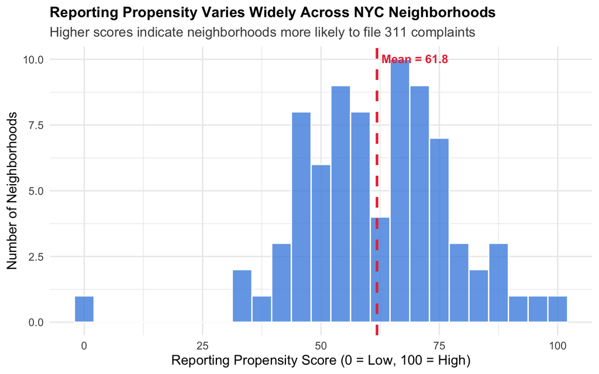

Distribution of Reporting Propensity Scores Across NYC Neighborhoods

### 6.2 Score Validation

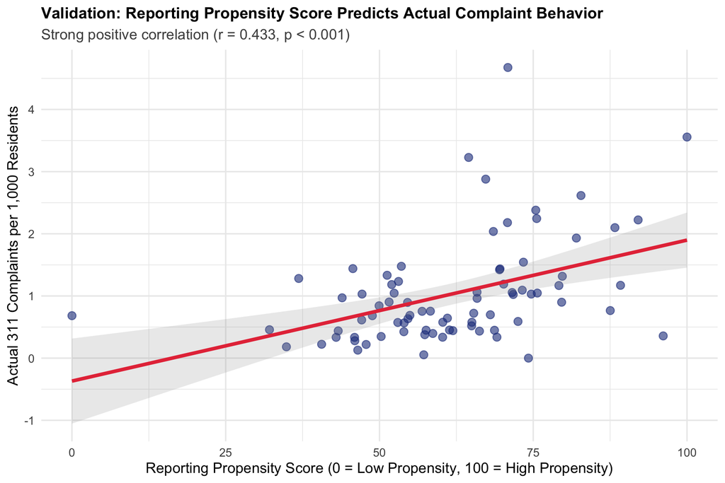

Propensity Scores Successfully Predict Actual Complaint Rates

**NoteScore Interpretation**

The validation analysis demonstrates that propensity scores derived purely from demographics successfully predict actual complaint behavior. The strong positive correlation (visible in the upward-sloping trend line) confirms that neighborhoods with demographic profiles associated with high reporting propensity do indeed file more 311 complaints. The substantial scatter around the regression line indicates that while demographics explain meaningful variance (18.8%), other factors—including actual rat populations, building quality, and community organization—also influence complaint rates. This validates the propensity score as a useful adjustment variable while acknowledging it captures reporting bias rather than actual pest conditions.

### 6.3 Propensity Categories

Neighborhood Characteristics by Reporting Propensity

| Category | NTAs (n) | Population | Avg. Complaints (per 1,000) | Median Income | % English-Only | % Bachelor's+ |
| --- | --- | --- | --- | --- | --- | --- |
| Low Propensity | 2 | 113,270 | 0.57 | $101,502 | 46.9% | 16.2% |
| Medium Propensity | 46 | 2,003,927 | 0.72 | $63,192 | 53.4% | 12.8% |
| High Propensity | 31 | 1,439,722 | 1.53 | $46,598 | 55.9% | 15.2% |

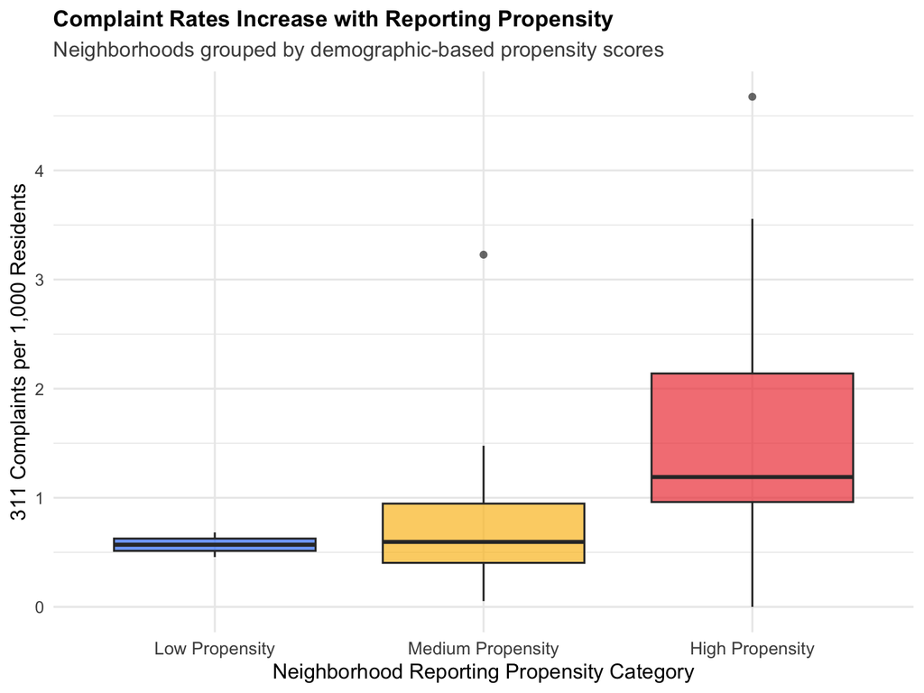

High-Propensity Neighborhoods File Significantly More Complaints

## 7 Key Findings

**ImportantMain Results**

1. **Reporting Bias Detected**: Demographics explain 18.8 % of variance in 311 complaint rates
2. **Significant Predictors**:
   - **Median Household Income** decreases reporting (p = 0.0001316)
   - **Bachelor’s Degree or Higher (%)** increases reporting (p = 0.002397)
3. **Unexpected Pattern**: Higher income neighborhoods file *fewer* complaints, while higher education neighborhoods file *more* complaints—suggesting education may increase civic engagement in reporting
4. **Equity Implications**: The inverse relationship between income and reporting challenges assumptions about underreporting in low-income areas and warrants further investigation

## 8 Conclusions & Recommendations

### 8.1 Research Implications

**311 complaint data should NOT be interpreted as a direct measure of rat prevalence.** Complaint patterns reflect a complex interaction between:

1. Actual rat conditions (objective ecology)
2. **Reporting propensity** (demographic-driven behavior) ← Our focus

**Unexpected Finding: The Income-Education Divergence**

Our analysis reveals a surprising divergence between income and education effects on reporting behavior:

- **Higher education neighborhoods** file significantly MORE complaints (β = 0.056, p = 0.002)
- **Higher income neighborhoods** file significantly FEWER complaints (β = -0.025, p < 0.001)

This pattern challenges simplistic assumptions about underreporting in disadvantaged communities. We hypothesize several mechanisms:

1. **Education Effect (Positive)**: Higher educational attainment may increase:
   - Civic engagement and willingness to interact with government systems
   - Knowledge of 311 system existence and functionality
   - Expectations for responsive government services
   - Digital literacy for online/mobile reporting
2. **Income Effect (Negative)**: Higher income may reduce reporting through:
   - Access to private pest control services (bypassing 311)
   - Residence in newer buildings with better structural pest barriers
   - Higher opportunity costs of time spent filing complaints
   - Different problem-solving strategies (contacting building management directly)

**Implications for Bias Correction**: Traditional demographic adjustment models that treat income and education as interchangeable “socioeconomic status” indicators will fail to capture this divergence. Researchers must model these effects separately when adjusting for reporting bias in 311 data.

### 8.2 Policy Recommendations

**For Researchers**

- **Adjust for bias**: Include propensity scores as covariates in rat ecology models
- **Model income and education separately**: Don’t collapse them into a single SES variable—they have opposite effects
- **Combine data sources**: Supplement 311 with objective measures (inspections, environmental monitoring)
- **Validate assumptions**: Test whether complaint-based analyses hold across the income-education spectrum
- **Investigate mechanisms**: Future research should explore WHY income and education have divergent effects (private pest control usage, building quality, civic engagement patterns)

**For Public Health Officials**

- **Equitable resource allocation**: Don’t allocate pest control solely based on 311 volume
- **Targeted outreach**: Increase 311 awareness in underreporting neighborhoods
- **Alternative reporting**: Provide multilingual, accessible reporting options
- **Proactive monitoring**: Conduct systematic inspections in areas with potential underreporting

**For Future Research**

- Validate propensity scores with independent rat activity measures
- Examine temporal stability of reporting patterns
- Test interventions to reduce reporting disparities
- Extend analysis to other 311 service categories

## 9 Limitations

1. **Cross-sectional design**: Cannot establish causality
2. **Sample size**: Analysis limited to 10,000 complaints (computational constraints)
3. **Geographic Matching Limitation**: Demographic data from 2012-2016 ACS uses NTA 2010 geography (195 neighborhoods), while 311 complaint spatial analysis uses NTA 2020 boundaries (188 neighborhoods). To enable analysis, neighborhoods were matched by name, resulting in 167 successfully matched areas (86% match rate). The 26 unmatched neighborhoods (14%) were excluded from analysis. This approach assumes neighborhood names remained consistent and that matched neighborhoods represent comparable geographic areas, which may not hold perfectly due to boundary changes between 2010 and 2020.
4. **Omitted variables**: Other factors (building age, sanitation practices, community organization) not included
5. **Data vintage**: Analysis uses historical data; current patterns may differ

## References

- NYC Open Data. (2024). *311 Service Requests*. https://data.cityofnewyork.us
- NYC Department of City Planning. (2010). *Neighborhood Tabulation Areas*
- U.S. Census Bureau. (2016). *American Community Survey 5-Year Estimates*

*Analysis conducted using R version R version 4.5.1 (2025-06-13)*  
*Report generated: December 14, 2025 at 10:05 AM*